# Model.Branum

Michael (Branum) Stephan, Jaclyn Coate, Josh Eysenbach

4/18/2020

I’m going to spend the first part of this markdown making some reproducible functions for later analysis. The following function sets the model label for using in other functions later on.

```r
# set model labels in order to easily identify them in other functions
set_model_label<- function(model, label){
  model$modelInfo$label <- label
  return(model)
}
```

The function below makes predictions on the dataset for all models.

```r
# let's store this as a function as we progress through additional EDA
make_predictions <- function(model_list, test_dataframe, predCol){

# creating list output
result = matrix(nrow = length(model_list), ncol=4)
x = 1

# iterate each item, predict, and gather statistics
for (item in model_list){
  # make model predictions
  predictions <- predict(item, newdata = test_dataframe)
  cm <- confusionMatrix(predictions, test_dataframe[,predCol])

  model_name <- item$modelInfo$label
  sensitivity <- cm$byClass["Sensitivity"]
  specificity <- cm$byClass["Specificity"]
  accuracy <- cm$overall["Accuracy"]

  result[x, 1] <- model_name
  result[x, 2] <- sensitivity
  result[x, 3] <- specificity
  result[x, 4] <- accuracy
  x = x + 1
}
df_out <- as.data.frame(result)
colnames(df_out) = c("model_name", "sensitivity", "specificity", "accuracy")

# converting data types
df_out$sensitivity <- as.numeric(as.character(df_out$sensitivity))
df_out$specificity <- as.numeric(as.character(df_out$specificity))
df_out$accuracy<- as.numeric(as.character(df_out$accuracy))
return(df_out)
}
```

The function below generates bar plots based on the model predictions.

```r
# create comparative bar plots for models based on their predictions
model_bar_plots <- function(df){
output_list = list()
i = 1
for(column in c("sensitivity", "specificity", "accuracy")){
p <- df %>% ggplot(aes_string(fill = "model_name", x = "model_name", y = column)) + geom_bar(stat = "identity")  + ggtitle(paste("Model Comparison - ", column, sep = "")) + theme(axis.text.x = element_text(angle = 90, hjust = 1)) + coord_cartesian(ylim = c(min(df[,column]) - 0.1, max(df[,column]) + 0.1)) + labs(fill="Model Version")
  output_list[[i]] = p
  i = i + 1
}
#do.call(grid.arrange, output_list)
for(item in output_list){
  print(item)
}
}
```

The function below generates roc curves for all the models in a list.

```r
# build a function to generate ROC plots
generate_roc_plots <- function(model_list, roc_header, names_list = NULL, showplots=FALSE){

  # check for user default label entered
  if(is.null(names_list)){
    names_list = c()

    # iterate each model for their respective labels
    i = 1
    for(model in model_list){
    names_list[i] = model$modelInfo$label
    i = i + 1
    }
  }
  roc <- evalm(model_list, gnames=names_list, showplots=showplots)$roc
  roc <- roc + ggtitle(roc_header)
  print(roc)
}
```

The following function combines predictions, bar plots, and roc plots from one convenient function.

```r
# function to generate comparative bar plots and ROC plots
compare_models <- function(model_list, test_dataframe, predCol){
  # sensitivity, specificity, accuracy
  model_bar_plots(make_predictions(model_list, test_dataframe, predCol))

  # ROC
  generate_roc_plots(model_list)
}
```

Now we will read in the data files. We decided to create one single data set to train and test on in order to compare “apples to apples”.

```r
# create training set
df.train <- data.frame(read.csv("https://raw.githubusercontent.com/JaclynCoate/6372_Project_2/master/Data/Training_Test_Splits/banktrain_raw.csv"))
df.train <- select(df.train, -duration) #drop duration. This variable cannot be determined before the call is made so it cannot be included in models.

# create test set
df.test <- data.frame(read.csv("https://raw.githubusercontent.com/JaclynCoate/6372_Project_2/master/Data/Training_Test_Splits/banktest_raw.csv"))
df.test <- select(df.test, -duration) #drop duration. This variable cannot be determined before the call is made so it cannot be included in models.

# yes is not available in the training set
df.test <- df.test %>% filter(default != "yes")

# display training set
skimr::skim(df.train)
```

Data summary

| Name | df.train |
| --- | --- |
| Number of rows | 4718 |
| Number of columns | 21 |
| _______________________ |  |
| Column type frequency: |  |
| factor | 11 |
| numeric | 10 |
| ________________________ |  |
| Group variables | None |

**Variable type: factor**

| skim_variable | n_missing | complete_rate | ordered | n_unique | top_counts |
| --- | --- | --- | --- | --- | --- |
| job | 0 | 1 | FALSE | 12 | adm: 1311, blu: 893, tec: 698, ser: 406 |
| marital | 0 | 1 | FALSE | 4 | mar: 2710, sin: 1485, div: 506, unk: 17 |
| education | 0 | 1 | FALSE | 8 | uni: 1544, hig: 1079, bas: 606, pro: 569 |
| default | 0 | 1 | FALSE | 2 | no: 3962, unk: 756 |
| housing | 0 | 1 | FALSE | 3 | yes: 2481, no: 2129, unk: 108 |
| loan | 0 | 1 | FALSE | 3 | no: 3925, yes: 685, unk: 108 |
| contact | 0 | 1 | FALSE | 2 | cel: 3391, tel: 1327 |
| month | 0 | 1 | FALSE | 10 | may: 1282, jul: 783, aug: 699, jun: 602 |
| day_of_week | 0 | 1 | FALSE | 5 | thu: 1040, wed: 953, mon: 941, tue: 922 |
| poutcome | 0 | 1 | FALSE | 3 | non: 3707, fai: 523, suc: 488 |
| Subscription | 0 | 1 | FALSE | 2 | no: 2362, yes: 2356 |

**Variable type: numeric**

| skim_variable | n_missing | complete_rate | mean | sd | p0 | p25 | p50 | p75 | p100 | hist |
| --- | --- | --- | --- | --- | --- | --- | --- | --- | --- | --- |
| age | 0 | 1 | 40.34 | 11.85 | 17.00 | 31.00 | 38.00 | 48.00 | 98.00 | ▆▇▃▁▁ |
| campaign | 0 | 1 | 2.34 | 2.36 | 1.00 | 1.00 | 2.00 | 3.00 | 43.00 | ▇▁▁▁▁ |
| pdays | 0 | 1 | 886.80 | 314.44 | 0.00 | 999.00 | 999.00 | 999.00 | 999.00 | ▁▁▁▁▇ |
| previous | 0 | 1 | 0.31 | 0.69 | 0.00 | 0.00 | 0.00 | 0.00 | 6.00 | ▇▁▁▁▁ |
| emp_var_rate | 0 | 1 | -0.49 | 1.73 | -3.40 | -1.80 | -0.10 | 1.40 | 1.40 | ▃▆▁▁▇ |
| cons_price_idx | 0 | 1 | 93.48 | 0.64 | 92.20 | 92.89 | 93.44 | 93.99 | 94.77 | ▂▇▂▇▂ |
| cons_conf_idx | 0 | 1 | -40.18 | 5.33 | -50.80 | -42.70 | -41.80 | -36.40 | -26.90 | ▇▇▃▇▃ |
| euribor3m | 0 | 1 | 2.97 | 1.89 | 0.63 | 1.24 | 4.02 | 4.96 | 5.04 | ▇▁▁▁▇ |
| nr_employed | 0 | 1 | 5136.19 | 86.48 | 4963.60 | 5076.20 | 5191.00 | 5228.10 | 5228.10 | ▂▁▅▁▇ |
| row | 0 | 1 | 24821.99 | 12454.11 | 7.00 | 14311.00 | 27457.50 | 36756.25 | 41187.00 | ▃▃▃▅▇ |

```r
skimr::skim(df.test)
```

Data summary

| Name | df.test |
| --- | --- |
| Number of rows | 36467 |
| Number of columns | 21 |
| _______________________ |  |
| Column type frequency: |  |
| factor | 11 |
| numeric | 10 |
| ________________________ |  |
| Group variables | None |

**Variable type: factor**

| skim_variable | n_missing | complete_rate | ordered | n_unique | top_counts |
| --- | --- | --- | --- | --- | --- |
| job | 0 | 1 | FALSE | 12 | adm: 9111, blu: 8361, tec: 6043, ser: 3563 |
| marital | 0 | 1 | FALSE | 4 | mar: 22215, sin: 10083, div: 4106, unk: 63 |
| education | 0 | 1 | FALSE | 8 | uni: 10624, hig: 8435, bas: 5439, pro: 4672 |
| default | 0 | 1 | FALSE | 2 | no: 28626, unk: 7841, yes: 0 |
| housing | 0 | 1 | FALSE | 3 | yes: 19094, no: 16491, unk: 882 |
| loan | 0 | 1 | FALSE | 3 | no: 30022, yes: 5563, unk: 882 |
| contact | 0 | 1 | FALSE | 2 | cel: 22750, tel: 13717 |
| month | 0 | 1 | FALSE | 10 | may: 12487, jul: 6391, aug: 5477, jun: 4716 |
| day_of_week | 0 | 1 | FALSE | 5 | thu: 7583, mon: 7573, wed: 7181, tue: 7165 |
| poutcome | 0 | 1 | FALSE | 3 | non: 31854, fai: 3728, suc: 885 |
| Subscription | 0 | 1 | FALSE | 2 | no: 34183, yes: 2284 |

**Variable type: numeric**

[output not shown]

```r
# specifying internal cv
fitControl <- trainControl(
  method = "cv",
  number = 10,
  savePredictions = T,
  summaryFunction=twoClassSummary,
  classProbs=T,
)
```

Now, we will run the base logistic regression model on all features to get a baseline value.

```r
logistic.base <- train(Subscription ~., data=df.train, method="glm", family=binomial(), trControl=fitControl)
summary(logistic.base)
```

```
##
## Call:
## NULL
##
## Deviance Residuals:
##     Min       1Q   Median       3Q      Max
## -3.2863  -0.8560  -0.4501   0.8025   2.1035
##
## Coefficients: (1 not defined because of singularities)
##                                Estimate Std. Error z value Pr(>|z|)
## (Intercept)                  -2.385e+02  7.244e+01  -3.293 0.000993 ***
## age                          -2.514e-03  4.230e-03  -0.594 0.552410
## `jobblue-collar`              1.157e-01  1.338e-01   0.865 0.387178
## jobentrepreneu                3.610e-01  1.997e-01   1.807 0.070685 .
## jobhousemaid                 -7.763e-02  2.399e-01  -0.324 0.746232
## jobmanagement                -2.443e-02  1.469e-01  -0.166 0.867922
## jobretired                    7.476e-01  2.097e-01   3.566 0.000363 ***
## `jobself-employ`              2.916e-01  1.953e-01   1.493 0.135372
## jobservices                   1.681e-01  1.417e-01   1.186 0.235631
## jobstudent                    4.109e-01  2.337e-01   1.758 0.078685 .
## jobtechnician                 7.594e-02  1.240e-01   0.612 0.540252
## jobunemployed                 3.278e-01  2.435e-01   1.346 0.178337
## jobunknown                    5.200e-01  3.917e-01   1.327 0.184384
## maritalmarried               -9.413e-02  1.161e-01  -0.811 0.417413
## maritalsingle                -5.320e-02  1.307e-01  -0.407 0.684035
## maritalunknown                3.075e-01  5.892e-01   0.522 0.601789
## educationbasic.6y             1.785e-01  1.953e-01   0.914 0.360807
## educationbasic.9y            -3.939e-02  1.553e-01  -0.254 0.799808
## educationhigh.school          8.731e-02  1.585e-01   0.551 0.581611
## educationilliterate           1.199e+01  1.886e+02   0.064 0.949297
## educationprofessional.course  6.934e-02  1.768e-01   0.392 0.694908
## educationuniversity.degree    3.109e-01  1.599e-01   1.944 0.051852 .
## educationunknown              4.825e-02  2.152e-01   0.224 0.822591
## defaultunknown               -2.621e-01  1.003e-01  -2.613 0.008980 **
## housingunk                   -1.155e-01  2.417e-01  -0.478 0.632647
## housingyes                    7.217e-02  7.119e-02   1.014 0.310687
## loanunk                              NA         NA      NA       NA
## loanyes                       1.928e-01  9.849e-02   1.958 0.050287 .
## contacttelephone             -6.374e-01  1.359e-01  -4.692 2.71e-06 ***
## monthaug                      4.437e-01  3.171e-01   1.399 0.161722
```

[output cut: 18 more lines]

```
## cons_price_idx                2.192e+00  4.919e-01   4.456 8.34e-06 ***
## cons_conf_idx                 2.050e-02  1.755e-02   1.168 0.242757
## euribor3m                     5.949e-01  2.738e-01   2.173 0.029803 *
## nr_employed                   6.414e-03  5.683e-03   1.129 0.259004
## row                           2.808e-05  1.473e-05   1.906 0.056622 .
## ---
## Signif. codes:  0 '***' 0.001 '**' 0.01 '*' 0.05 '.' 0.1 ' ' 1
##
## (Dispersion parameter for binomial family taken to be 1)
##
##     Null deviance: 6540.5  on 4717  degrees of freedom
## Residual deviance: 4995.1  on 4666  degrees of freedom
## AIC: 5099.1
##
## Number of Fisher Scoring iterations: 11
```

```r
varImp(logistic.base)
```

```
## glm variable importance
##
##   only 20 most important variables shown (out of 51)
##
##                            Overall
## emp_var_rate                100.00
## monthmar                     81.00
## contacttelephone             80.80
## cons_price_idx               76.69
## jobretired                   61.15
## monthjun                     54.52
## day_of_weekmon               51.84
## campaign                     51.22
## pdays                        48.22
## defaultunknown               44.51
## monthnov                     42.83
## monthmay                     40.95
## monthdec                     39.24
## euribor3m                    36.82
## day_of_weekwed               35.74
## poutcomenonexistent          35.38
## day_of_weekthu               34.92
## loanyes                      33.07
## educationuniversity.degree   32.84
## row                          32.17
```

Training the base case KNN model on all the same features.

```r
knn.base <- train(Subscription ~., data=df.train, method = "knn", trControl = fitControl, preProcess = c("center","scale"))

summary(knn.base)
```

```
##             Length Class      Mode
## learn        2     -none-     list
## k            1     -none-     numeric
## theDots      0     -none-     list
## xNames      52     -none-     character
## problemType  1     -none-     character
## tuneValue    1     data.frame list
## obsLevels    2     -none-     character
## param        0     -none-     list
```

Training the base case on all the same features as the KNN and Logistic models.

```r
rf.base <- train(Subscription ~., data=df.train, method="rf", trControl = fitControl)
summary(rf.base)
```

```
##                 Length Class      Mode
## call               4   -none-     call
## type               1   -none-     character
## predicted       4718   factor     numeric
## err.rate        1500   -none-     numeric
## confusion          6   -none-     numeric
## votes           9436   matrix     numeric
## oob.times       4718   -none-     numeric
## classes            2   -none-     character
## importance        52   -none-     numeric
## importanceSD       0   -none-     NULL
## localImportance    0   -none-     NULL
## proximity          0   -none-     NULL
## ntree              1   -none-     numeric
## mtry               1   -none-     numeric
## forest            14   -none-     list
## y               4718   factor     numeric
## test               0   -none-     NULL
## inbag              0   -none-     NULL
## xNames            52   -none-     character
## problemType        1   -none-     character
## tuneValue          1   data.frame list
## obsLevels          2   -none-     character
## param              0   -none-     list
```

Now, it’s time for our model comparison.

```r
# setting our model labels
knn.base <- set_model_label(knn.base, "Base KNN")
rf.base <- set_model_label(rf.base, "Base RF")
logistic.base <- set_model_label(logistic.base, "Base MLR")

# making our predictions metrics df for each model
preds.base <- make_predictions(list(logistic.base, knn.base, rf.base), df.test, "Subscription")
```

Now that we have our prediction metrics dataframe for the base modle, let’s generate a bar plot and ROC curve of our values and do a comparison.

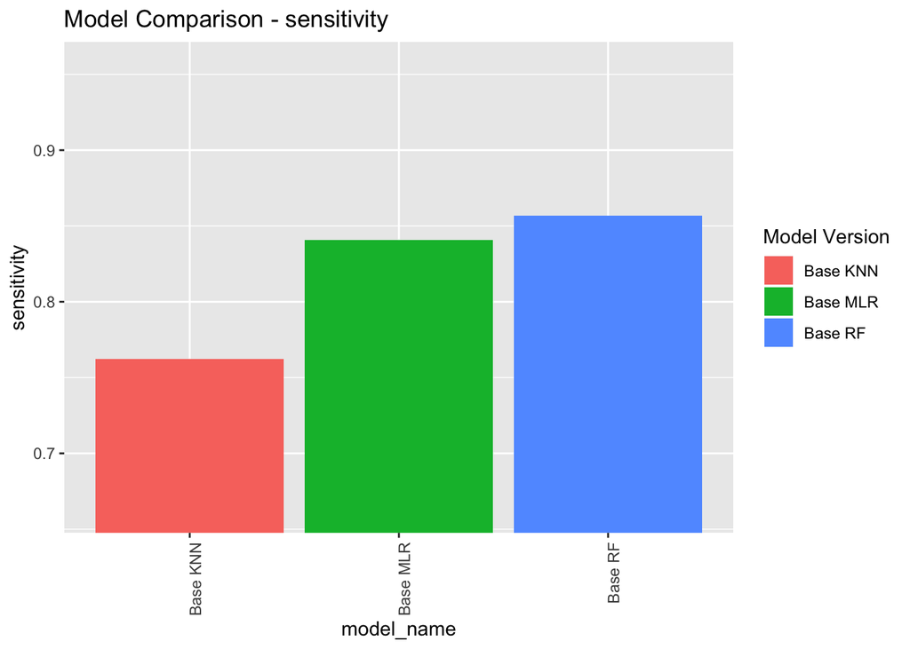

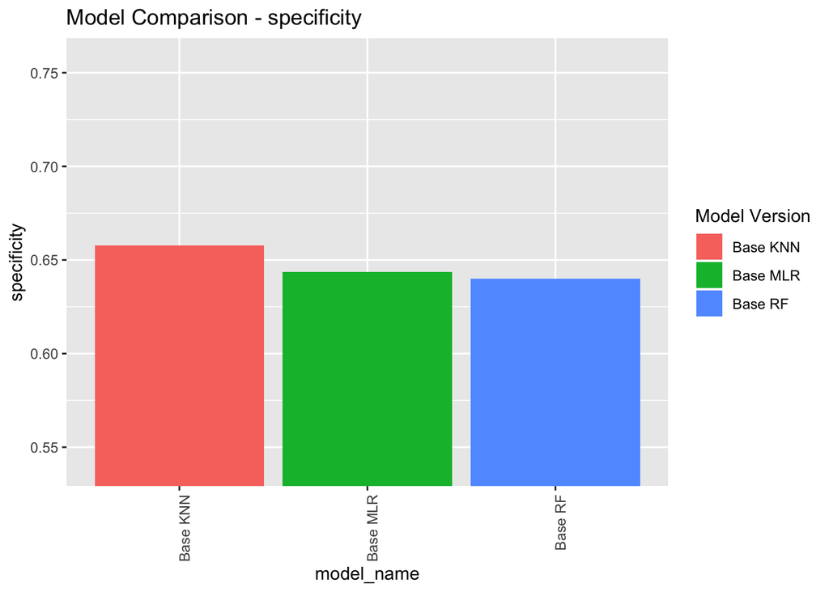

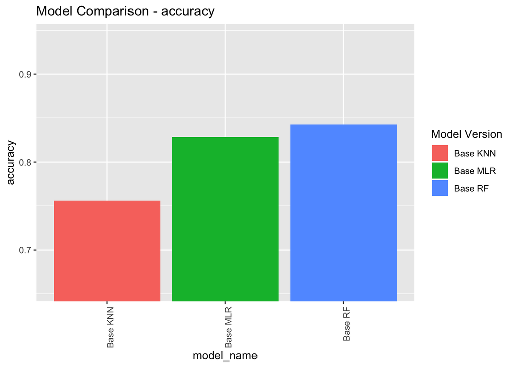

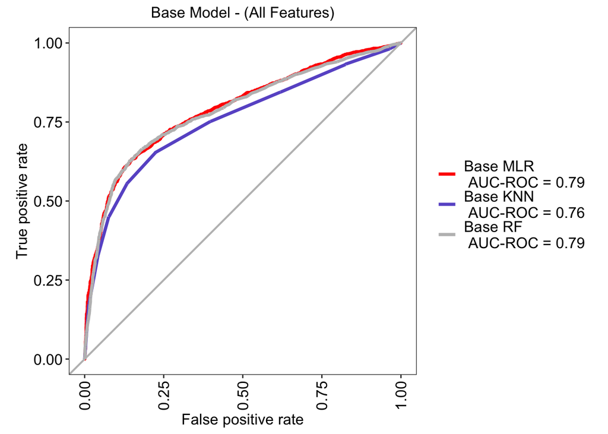

Based on the initial model, we have pretty good results, but the specificity is a little low. Let’s see if we can add some features to enhance the prediction capabilities of the model and then recompare. First, let’s remove non-significant variables based on the statistical significance of the logistic regression.

```r
summary(logistic.base)
```

```
##
## Call:
## NULL
##
## Deviance Residuals:
##     Min       1Q   Median       3Q      Max
## -3.2863  -0.8560  -0.4501   0.8025   2.1035
##
## Coefficients: (1 not defined because of singularities)
##                                Estimate Std. Error z value Pr(>|z|)
## (Intercept)                  -2.385e+02  7.244e+01  -3.293 0.000993 ***
## age                          -2.514e-03  4.230e-03  -0.594 0.552410
## `jobblue-collar`              1.157e-01  1.338e-01   0.865 0.387178
## jobentrepreneu                3.610e-01  1.997e-01   1.807 0.070685 .
## jobhousemaid                 -7.763e-02  2.399e-01  -0.324 0.746232
## jobmanagement                -2.443e-02  1.469e-01  -0.166 0.867922
## jobretired                    7.476e-01  2.097e-01   3.566 0.000363 ***
## `jobself-employ`              2.916e-01  1.953e-01   1.493 0.135372
## jobservices                   1.681e-01  1.417e-01   1.186 0.235631
## jobstudent                    4.109e-01  2.337e-01   1.758 0.078685 .
## jobtechnician                 7.594e-02  1.240e-01   0.612 0.540252
## jobunemployed                 3.278e-01  2.435e-01   1.346 0.178337
## jobunknown                    5.200e-01  3.917e-01   1.327 0.184384
## maritalmarried               -9.413e-02  1.161e-01  -0.811 0.417413
## maritalsingle                -5.320e-02  1.307e-01  -0.407 0.684035
## maritalunknown                3.075e-01  5.892e-01   0.522 0.601789
## educationbasic.6y             1.785e-01  1.953e-01   0.914 0.360807
## educationbasic.9y            -3.939e-02  1.553e-01  -0.254 0.799808
## educationhigh.school          8.731e-02  1.585e-01   0.551 0.581611
## educationilliterate           1.199e+01  1.886e+02   0.064 0.949297
## educationprofessional.course  6.934e-02  1.768e-01   0.392 0.694908
## educationuniversity.degree    3.109e-01  1.599e-01   1.944 0.051852 .
## educationunknown              4.825e-02  2.152e-01   0.224 0.822591
## defaultunknown               -2.621e-01  1.003e-01  -2.613 0.008980 **
## housingunk                   -1.155e-01  2.417e-01  -0.478 0.632647
## housingyes                    7.217e-02  7.119e-02   1.014 0.310687
## loanunk                              NA         NA      NA       NA
## loanyes                       1.928e-01  9.849e-02   1.958 0.050287 .
## contacttelephone             -6.374e-01  1.359e-01  -4.692 2.71e-06 ***
## monthaug                      4.437e-01  3.171e-01   1.399 0.161722
```

[output cut: 18 more lines]

```
## cons_price_idx                2.192e+00  4.919e-01   4.456 8.34e-06 ***
## cons_conf_idx                 2.050e-02  1.755e-02   1.168 0.242757
## euribor3m                     5.949e-01  2.738e-01   2.173 0.029803 *
## nr_employed                   6.414e-03  5.683e-03   1.129 0.259004
## row                           2.808e-05  1.473e-05   1.906 0.056622 .
## ---
## Signif. codes:  0 '***' 0.001 '**' 0.01 '*' 0.05 '.' 0.1 ' ' 1
##
## (Dispersion parameter for binomial family taken to be 1)
##
##     Null deviance: 6540.5  on 4717  degrees of freedom
## Residual deviance: 4995.1  on 4666  degrees of freedom
## AIC: 5099.1
##
## Number of Fisher Scoring iterations: 11
```

It appears that job status, default status, month, day of week, emp_var_rate, cons_price_idx, and euribor3m are all significant, so let’s start by using only these values and retraining some new models and comparing.

```r
# creating a reduced set size
df.train.reduced <- df.train %>% select(Subscription, job, default, month, day_of_week, emp_var_rate, cons_price_idx, euribor3m, poutcome)

df.test.reduced <- df.test %>% select(Subscription, job, default, month, day_of_week, emp_var_rate, cons_price_idx, euribor3m, poutcome)
```

Now, let’s train our models with the new reduced dataset based on more significant variables.

```r
# training with a reduced data set
logistic.reduced <- train(Subscription ~., data=df.train.reduced, method="glm", family=binomial(), trControl=fitControl)
knn.reduced <- train(Subscription ~., data=df.train.reduced, method = "knn", trControl = fitControl, preProcess = c("center","scale"))
rf.reduced <- train(Subscription ~., data=df.train.reduced, method="rf", trControl = fitControl)
```

Let’s compare our reduced models and see how we did.

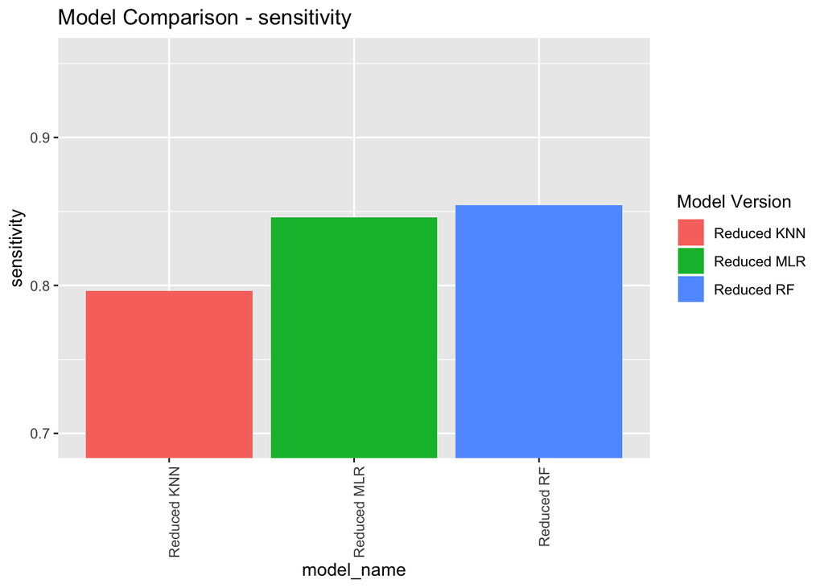

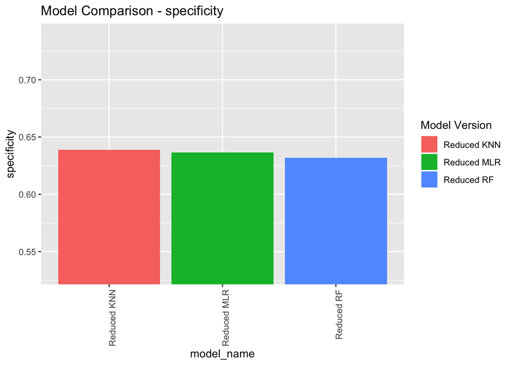

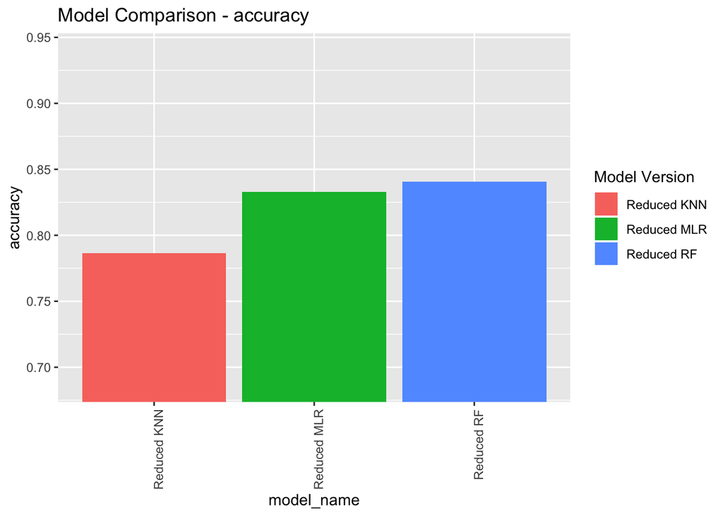

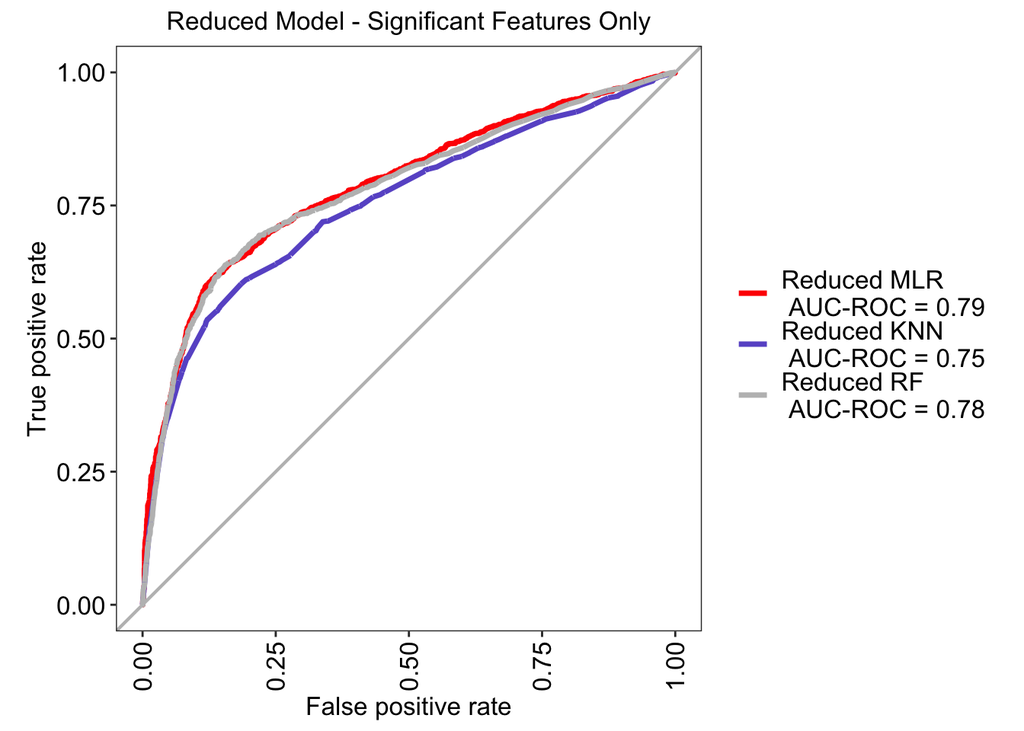

In looking at our reduced model, we don’t necessarily see any real benefit in performance other than a reduction in model complexity. Let’s next try the models with the “final” from the eda file and see how that compares to the reduced “base case” scenario.

```r
# add interaction for job/age and month/poutcome
df.train.engineered <- df.train.reduced %>%
  mutate(optimal_months = case_when(month == "sep" ~ 1, month == "oct" ~ 1, month == "mar" ~ 1, month == "dec" ~ 1, TRUE ~ 0), month_and_campaign = paste(optimal_months, poutcome, sep="_"), senior = case_when(df.train$age > 60 ~ 1, TRUE ~0), job_seniority = paste(job, senior, sep="_"),
defaulted = case_when(default == "unknown" ~ 1, default == "no" ~ 1, TRUE ~ 0)) %>%
  select(-one_of(c("poutcome", "month", "optimal_months", "job", "senior", "day_of_week", "default", "cons_price_idx", "euribor3m")))

# NOTE: SELF-EMPLOY_1 AND SERVICES_1 ARE NOT PRESENT JOB LEVELS IN THE ENGINEERED TRAINING SET. THEREFORE, I AM OPTING TO EXCLUDE THOSE LEVELS TO ALLOW FOR PREDICTIONS.
df.test.engineered <- df.test.reduced %>%
  mutate(optimal_months = case_when(month == "sep" ~ 1, month == "oct" ~ 1, month == "mar" ~ 1, month == "dec" ~ 1, TRUE ~ 0), month_and_campaign = paste(optimal_months, poutcome, sep="_"), senior = case_when(df.test$age > 60 ~ 1, TRUE ~0), job_seniority = paste(job, senior, sep="_"),
defaulted = case_when(default == "unknown" ~ 1, default == "no" ~ 1, TRUE ~ 0)) %>%
  select(-one_of(c("poutcome", "month", "optimal_months", "job", "senior", "day_of_week", "default", "cons_price_idx", "euribor3m"))) %>% filter(job_seniority != "self-employ_1" & job_seniority != "services_1")
```

Let’s check out our new data sets

```r
skim(df.train.engineered)
```

Data summary

| Name | df.train.engineered |
| --- | --- |
| Number of rows | 4718 |
| Number of columns | 5 |
| _______________________ |  |
| Column type frequency: |  |
| character | 2 |
| factor | 1 |
| numeric | 2 |
| ________________________ |  |
| Group variables | None |

**Variable type: character**

| skim_variable | n_missing | complete_rate | min | max | empty | n_unique | whitespace |
| --- | --- | --- | --- | --- | --- | --- | --- |
| month_and_campaign | 0 | 1 | 9 | 13 | 0 | 6 | 0 |
| job_seniority | 0 | 1 | 8 | 13 | 0 | 21 | 0 |

**Variable type: factor**

| skim_variable | n_missing | complete_rate | ordered | n_unique | top_counts |
| --- | --- | --- | --- | --- | --- |
| Subscription | 0 | 1 | FALSE | 2 | no: 2362, yes: 2356 |

**Variable type: numeric**

[output not shown]

```r
# training with a reduced data set
logistic.engineered <- train(Subscription ~., data=df.train.engineered, method="glm", family=binomial(), trControl=fitControl)
knn.engineered <- train(Subscription ~., data=df.train.engineered, method = "knn", trControl = fitControl, preProcess = c("center","scale"))
rf.engineered <- train(Subscription ~., data=df.train.engineered, method="rf", trControl = fitControl)
```

Now, let’s compare our final, engineered models.

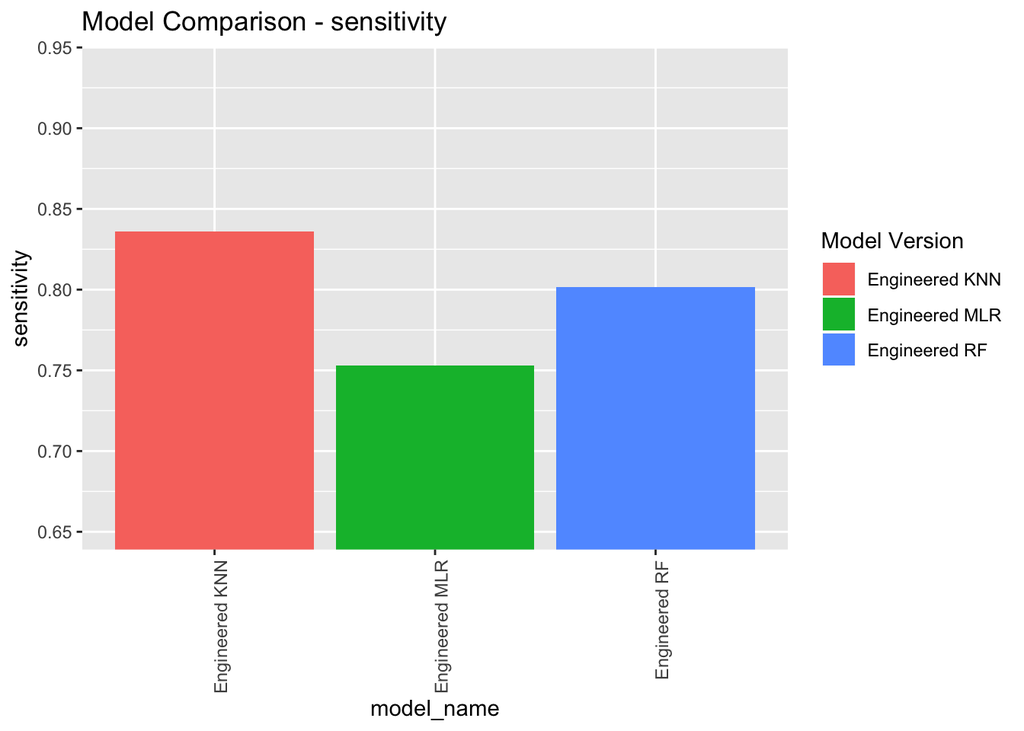

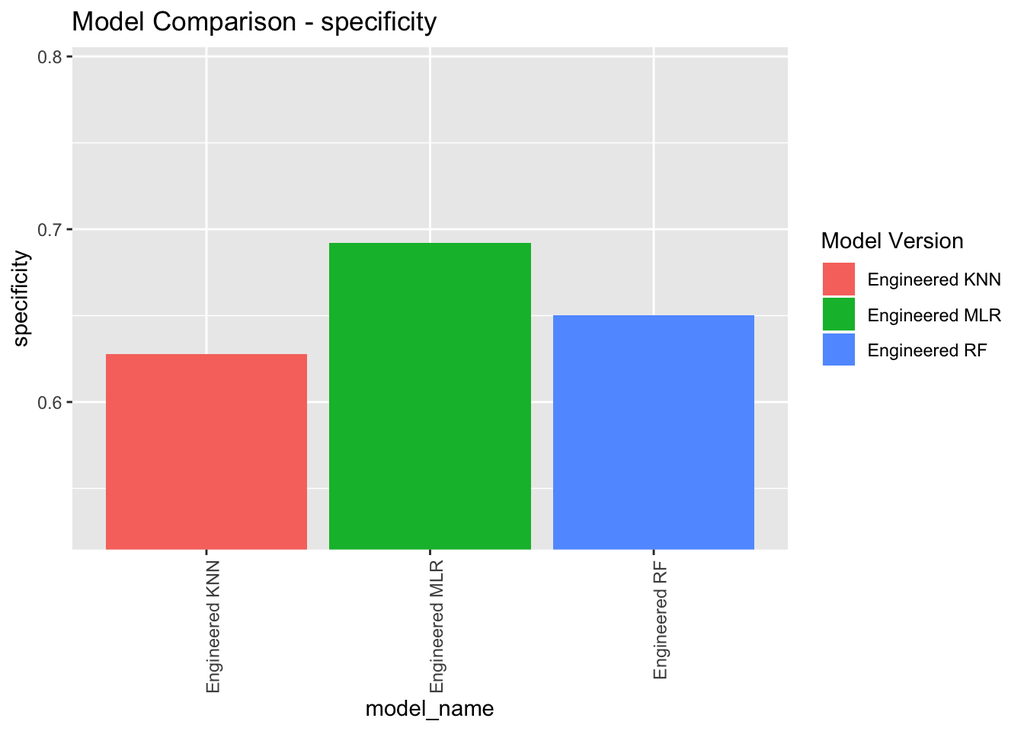

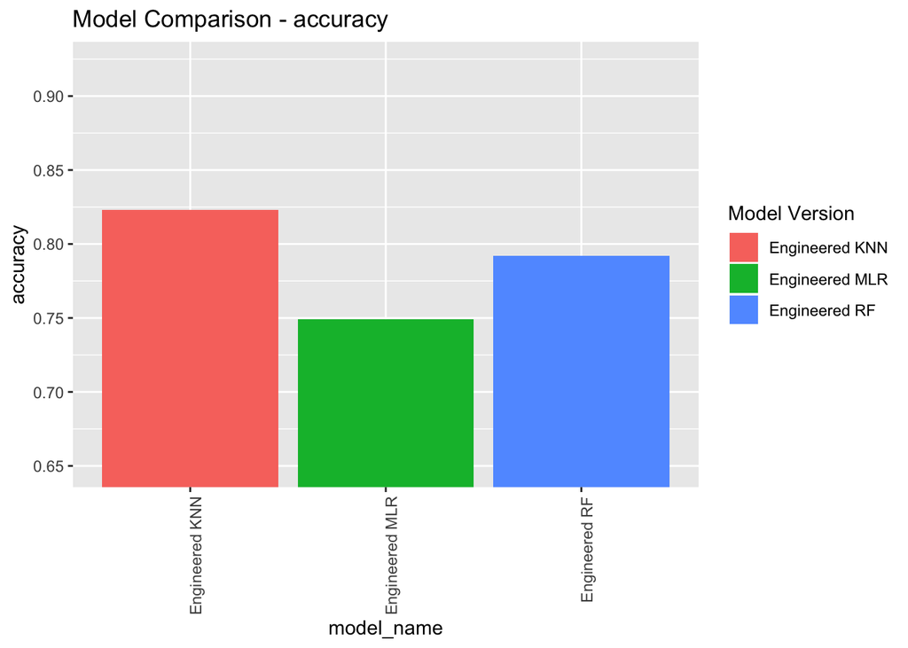

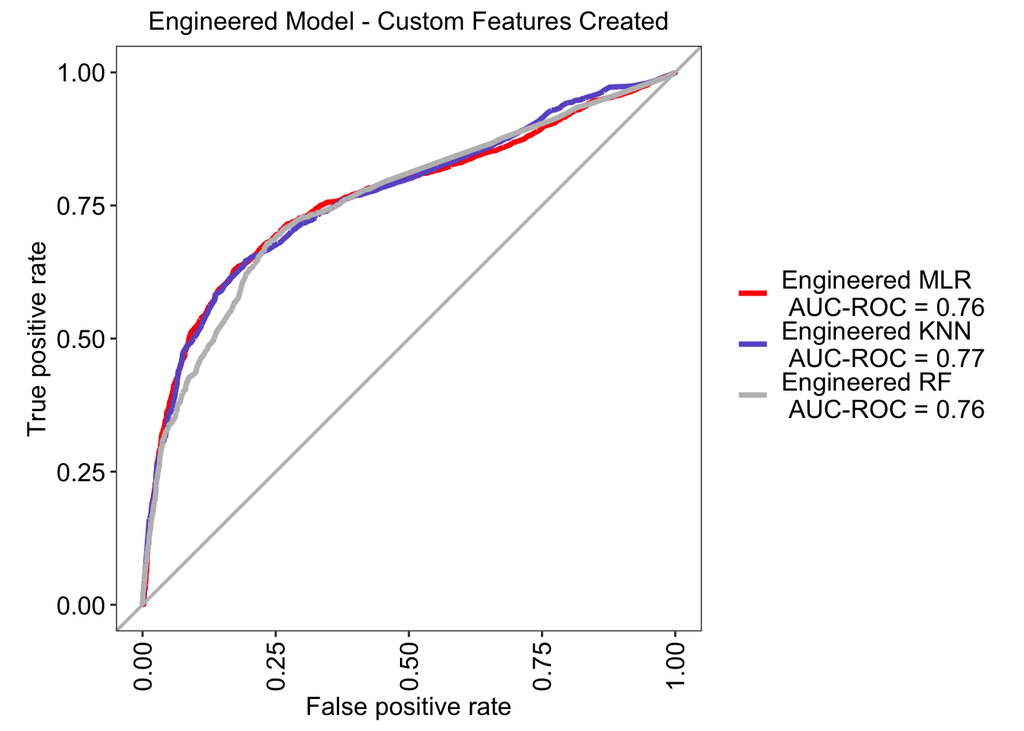

Finally, let’s do a cross comparison of each model against the other with different data sets.

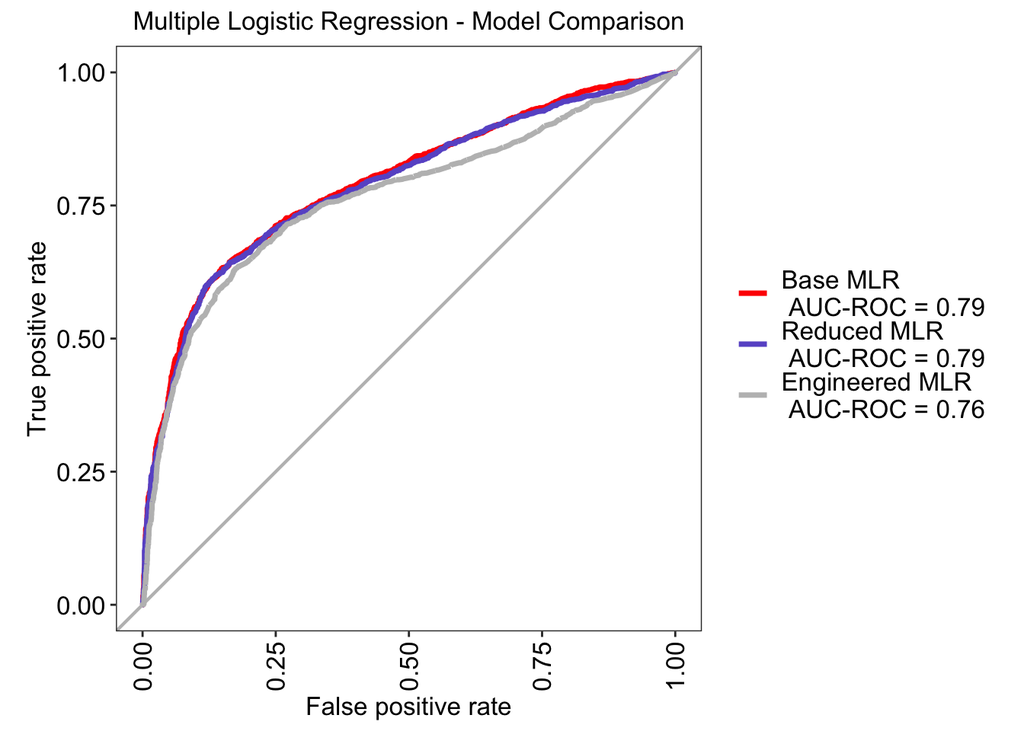

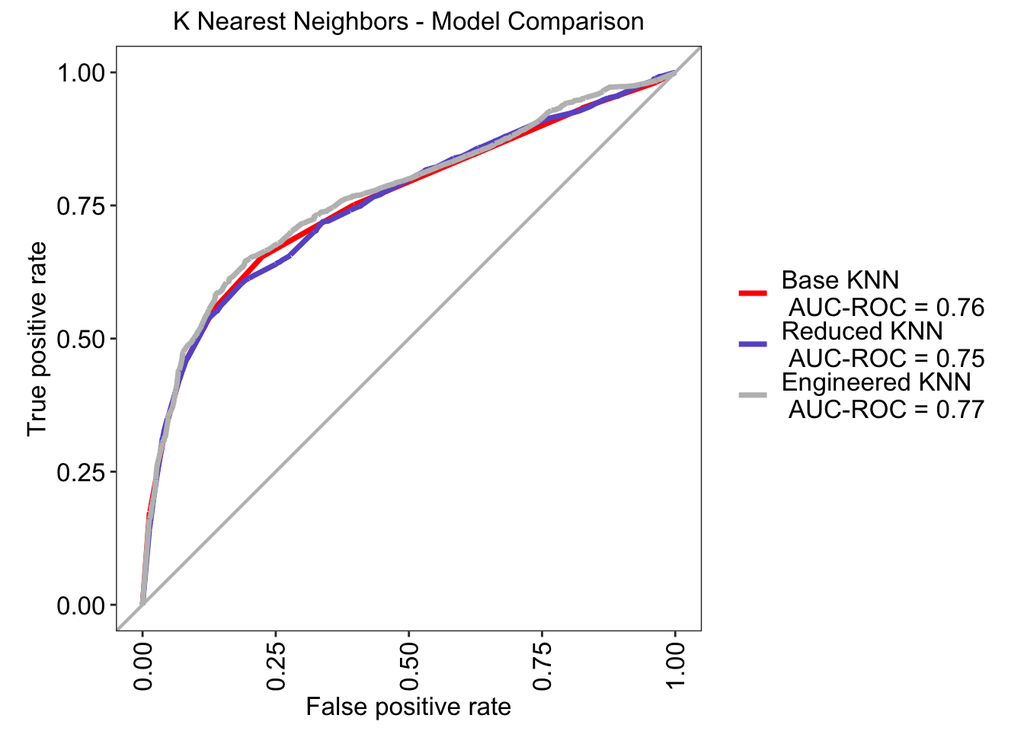

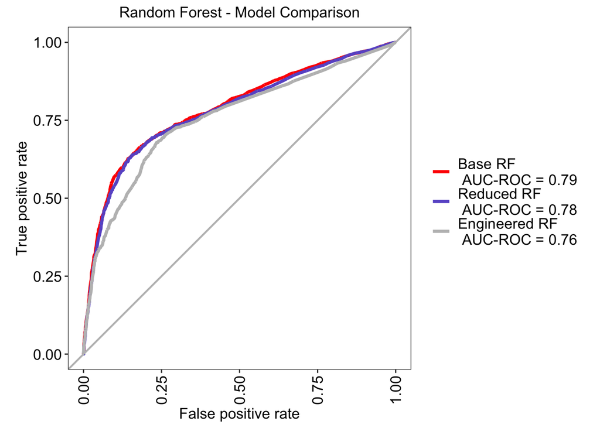